# Xavier Help

Hey Xavier, I thought this was a bit easier than email. This is made using what is called an rmd file, which let’s me write code and also comment.

What you’re first trying to do is create a dataframe with the data you have already written down. This is how we create a dataframe in R but if we were trying to store something like names and favorite drinks.

```r
x <- data.frame("names" = c("Tyler", "Trey", "Xavier"), "favorite_drink" = c("Gin and Tonic", "Some bullshit", "Juul flavored vodka"))
```

Now let’s look at the dataframe we made

```r
print(x)
```

```
##    names      favorite_drink
## 1  Tyler       Gin and Tonic
## 2   Trey       Some bullshit
## 3 Xavier Juul flavored vodka
```

So for you, you need to start by making the dataframe from your spreadsheet, but you want to make sure to format it correctly. A good rule of thumb is that each row should only have one subject (in the previous case, each row was about a different person), and each cell should have one value in it. Yours might look something like this.

```r
Xavier_Dataframe <- data.frame("Rock" = c("C", "C", "C", "A", "A", "A"), "count" = c(17,17,16,23,23,20), "counting_number" = c(1,2,3,1,2,3))
```

You would continue this through F and H. Let’s look at our dataframe now.

```r
print(Xavier_Dataframe)
```

```
##   Rock count counting_number
## 1    C    17               1
## 2    C    17               2
## 3    C    16               3
## 4    A    23               1
## 5    A    23               2
## 6    A    20               3
```

Now using this you can start answering the questions. You can use the plot function, which takes an x and y and guesses what graph you want, to approach the variance question.

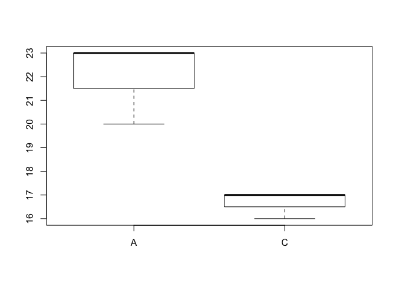

```r
plot(Xavier_Dataframe$Rock, Xavier_Dataframe$count)
```

I hope this helps you out! Let me know if I can help more.